# APRESENTAÇÃO REGRESSÃO

Ivan Maia

13 de outubro de 2019

### BASE DE DADOS

Título: Banco de Dados da Pesquisa - Banda Larga Fixa

Descrição: Banco de dados das entrevistas da pesquisa de satisfação e qualidade percebida relativa à prestação do Serviço de Comunicação Multimídia - SCM (banda larga fixa)

### Variáveis:

SATISFAÇÃO GERAL

SEXO

RENDA

IDADE

ESTADO

REGIAO

OPERADORA

B: Oferta e Contratação

B1_1 : Nota atribuída com respeito à facilidade de entendimento dos planos e serviços contratados.

B1_2 : Nota atribuída com respeito ao comprometimento da operadora em cumprir o que foi prometido e divulgado em sua publicidade.

C: Funcionamento

C1_1: Notas atribuídas à cobrança de valores na conta de acordo com o contratado.

C1_2: Notas atribuídas à capacidade de manter a conexão sem quedas.

C1_3: Notas atribuídas à velocidade de navegação.

D: Cobrança

D1_1: Notas atribuídas à cobrança dos valores na conta de acordo com o contratado.

D1_2: Notas atribuídas à clareza das informações na conta.

A2: Atendimento

A2_1: Notas atribuídas ao tempo de espera para falar com o atendente.

A2_2: Notas atribuídas à necessidade de repetir a demanda.

A2_3: Notas atribuídas à capacidade de esclarecimento por parte dos atendentes.

A3: Notas atribuídas à qualidade do Atendimento Telefônico da operadora.

A4: Notas atribuídas à qualidade do Atendimento pela Internet da operadora.

E: Capacidade de Resolução

E2 :Nota atribuída à resolução do problema de cobrança da prestadora citada.

E4: Nota atribuída à resolução da alteração do plano ou condição comercial.

F: Reparo e Instalação

F2_1: Notas atribuídas ao tempo de espera entre a solicitação de instalação e a visita do técnico.

F2_2: Cumprimento do prazo acordado para instalação.

F2_3: Qualidade da instalação do serviço.

F4_1: Notas atribuídas ao tempo de espera entre a solicitação de reparo e a visita do técnico.

F4_2: Cumprimento do prazo acordado para reparo.

F4_3: Qualidade do reparo do serviço.

## TRANSFORMAÇÃO DA BASE DE DADOS

```
##  OPERADORA      ESTADO    SEXO       ANO_BASE        IDADE
##  GVT : 64   CE     : 65   F:501   Min.   :2015   Min.   :18.00
##  NET :213   PE     : 53   M:420   1st Qu.:2015   1st Qu.:30.00
##  OI  :411   DF     : 50           Median :2016   Median :38.00
##  SKY :129   AM     : 46           Mean   :2016   Mean   :39.65
##  VIVO:104   GO     : 46           3rd Qu.:2017   3rd Qu.:49.00
##             MA     : 46           Max.   :2018   Max.   :84.00
##             (Other):615
##      RENDA       SATISFACAO_GERAL      B1_1             B1_2
##  Min.   :  300   Min.   : 0.000   Min.   : 0.000   Min.   : 0.000
##  1st Qu.: 1800   1st Qu.: 4.000   1st Qu.: 4.000   1st Qu.: 3.000
##  Median : 3000   Median : 6.000   Median : 6.000   Median : 6.000
##  Mean   : 4483   Mean   : 5.733   Mean   : 5.941   Mean   : 5.378
##  3rd Qu.: 5000   3rd Qu.: 8.000   3rd Qu.: 8.000   3rd Qu.: 8.000
##  Max.   :50000   Max.   :10.000   Max.   :10.000   Max.   :10.000
##
##       C1_1         C1_2            C1_3             D1_1
##  Min.   : 0   Min.   : 0.00   Min.   : 0.000   Min.   : 0.000
##  1st Qu.: 4   1st Qu.: 3.00   1st Qu.: 3.000   1st Qu.: 3.000
##  Median : 7   Median : 6.00   Median : 6.000   Median : 6.000
##  Mean   : 6   Mean   : 5.39   Mean   : 5.511   Mean   : 5.616
##  3rd Qu.: 8   3rd Qu.: 8.00   3rd Qu.: 8.000   3rd Qu.: 8.000
##  Max.   :10   Max.   :10.00   Max.   :10.000   Max.   :10.000
##
##       D1_2              E2               E4              F2_1
##  Min.   : 0.000   Min.   : 0.000   Min.   : 0.000   Min.   : 0.00
##  1st Qu.: 4.000   1st Qu.: 3.000   1st Qu.: 3.000   1st Qu.: 4.00
##  Median : 7.000   Median : 5.000   Median : 6.000   Median : 7.00
##  Mean   : 6.173   Mean   : 5.251   Mean   : 5.593   Mean   : 6.23
##  3rd Qu.: 9.000   3rd Qu.: 8.000   3rd Qu.: 8.000   3rd Qu.: 9.00
##  Max.   :10.000   Max.   :10.000   Max.   :10.000   Max.   :10.00
##
##       F2_2             F2_3             F4_1             F4_2
##  Min.   : 0.000   Min.   : 0.000   Min.   : 0.000   Min.   : 0.000
##  1st Qu.: 4.000   1st Qu.: 5.000   1st Qu.: 4.000   1st Qu.: 4.000
##  Median : 7.000   Median : 8.000   Median : 7.000   Median : 7.000
##  Mean   : 6.368   Mean   : 6.915   Mean   : 5.889   Mean   : 6.005
##  3rd Qu.: 9.000   3rd Qu.:10.000   3rd Qu.: 9.000   3rd Qu.: 9.000
##  Max.   :10.000   Max.   :10.000   Max.   :10.000   Max.   :10.000
##
##       F4_3            A2_1            A2_2             A2_3
##  Min.   : 0.00   Min.   : 0.00   Min.   : 0.000   Min.   : 0.000
##  1st Qu.: 3.00   1st Qu.: 2.00   1st Qu.: 2.000   1st Qu.: 4.000
##  Median : 7.00   Median : 5.00   Median : 5.000   Median : 7.000
##  Mean   : 6.02   Mean   : 5.09   Mean   : 5.167   Mean   : 6.217
##  3rd Qu.: 9.00   3rd Qu.: 8.00   3rd Qu.: 8.000   3rd Qu.: 9.000
##  Max.   :10.00   Max.   :10.00   Max.   :10.000   Max.   :10.000
##
##        A3               A4         REGIAO
##  Min.   : 0.000   Min.   : 0.000   CO:154
##  1st Qu.: 5.000   1st Qu.: 4.000   N :179
##  Median : 7.000   Median : 7.000   NE:366
##  Mean   : 6.175   Mean   : 6.004   S : 80
##  3rd Qu.: 9.000   3rd Qu.: 8.000   SO:142
##  Max.   :10.000   Max.   :10.000
##
```

## ANÁLISE DESCRITIVA

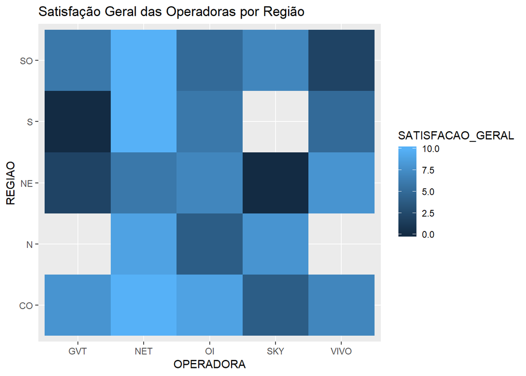

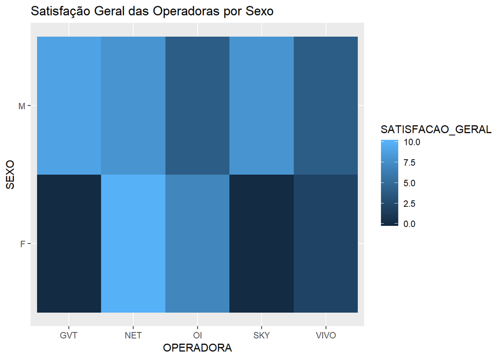

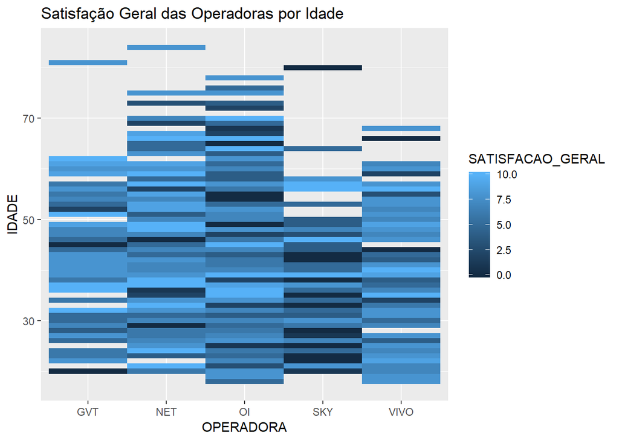

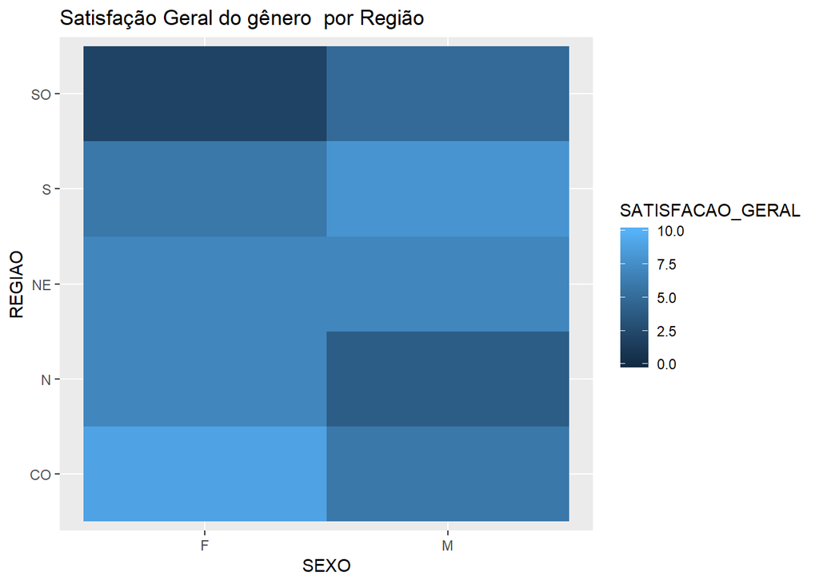

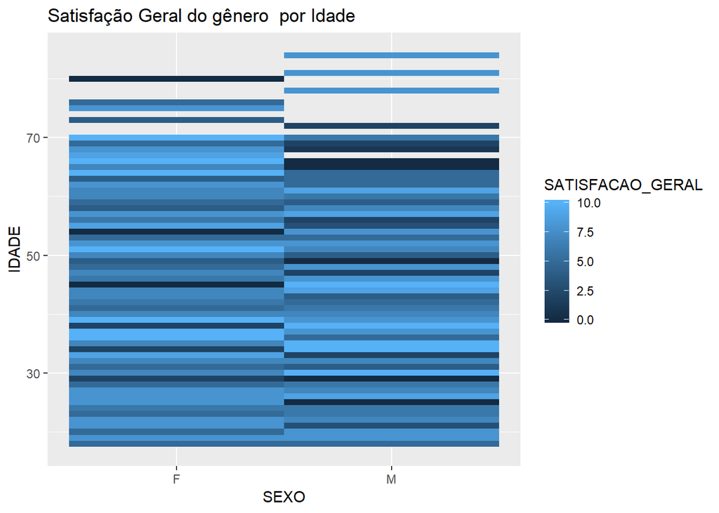

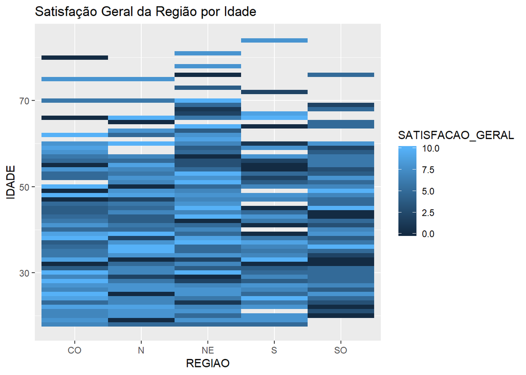

## REGRESSÃO

```r
modelo1 <- lm(formula = SATISFACAO_GERAL ~ B1_1 + B1_2 + C1_1 + C1_2 + C1_3 + D1_1 + D1_2 + E2 + E4 + F2_1 +
                  F2_2 + F2_3 + F4_1 + F4_2 + F4_3 + A2_1 + A2_2 + A2_3 + A3 + A4
                +SEXO + RENDA + REGIAO + IDADE, data = dados)
  summary(modelo1)
```

```
##
## Call:
## lm(formula = SATISFACAO_GERAL ~ B1_1 + B1_2 + C1_1 + C1_2 + C1_3 +
##     D1_1 + D1_2 + E2 + E4 + F2_1 + F2_2 + F2_3 + F4_1 + F4_2 +
##     F4_3 + A2_1 + A2_2 + A2_3 + A3 + A4 + SEXO + RENDA + REGIAO +
##     IDADE, data = dados)
##
## Residuals:
##     Min      1Q  Median      3Q     Max
## -7.5814 -0.8156  0.0347  0.8833  7.9513
##
## Coefficients:
##               Estimate Std. Error t value Pr(>|t|)
## (Intercept)  1.159e+00  2.717e-01   4.266 2.21e-05 ***
## B1_1         4.519e-02  2.984e-02   1.514  0.13026
## B1_2         2.503e-01  2.965e-02   8.443  < 2e-16 ***
## C1_1         1.407e-01  3.563e-02   3.949 8.48e-05 ***
## C1_2         1.260e-01  3.203e-02   3.934 8.99e-05 ***
## C1_3         2.148e-01  3.113e-02   6.900 9.86e-12 ***
## D1_1         7.604e-02  2.652e-02   2.868  0.00423 **
## D1_2        -7.348e-02  2.614e-02  -2.811  0.00505 **
## E2           1.967e-02  2.563e-02   0.768  0.44298
## E4           1.715e-02  2.655e-02   0.646  0.51851
## F2_1        -3.105e-02  3.040e-02  -1.021  0.30739
## F2_2        -9.410e-03  3.050e-02  -0.308  0.75778
## F2_3         3.281e-02  2.716e-02   1.208  0.22723
## F4_1        -1.468e-02  3.362e-02  -0.437  0.66238
## F4_2         5.876e-02  3.317e-02   1.772  0.07678 .
## F4_3        -3.996e-02  2.828e-02  -1.413  0.15797
## A2_1        -5.098e-02  2.387e-02  -2.136  0.03298 *
## A2_2         3.405e-02  2.803e-02   1.215  0.22483
## A2_3        -1.240e-02  2.944e-02  -0.421  0.67361
## A3           9.597e-02  3.180e-02   3.018  0.00261 **
## A4          -2.744e-02  2.856e-02  -0.961  0.33701
## SEXOM       -2.056e-01  1.093e-01  -1.882  0.06022 .
## RENDA       -5.753e-06  1.025e-05  -0.561  0.57460
## REGIAON      8.159e-02  1.769e-01   0.461  0.64477
## REGIAONE     2.806e-01  1.546e-01   1.815  0.06990 .
## REGIAOS     -6.953e-02  2.224e-01  -0.313  0.75462
## REGIAOSO    -5.877e-02  1.878e-01  -0.313  0.75436
## IDADE       -4.530e-03  4.289e-03  -1.056  0.29116
## ---
## Signif. codes:  0 '***' 0.001 '**' 0.01 '*' 0.05 '.' 0.1 ' ' 1
##
## Residual standard error: 1.594 on 893 degrees of freedom
## Multiple R-squared:  0.6966, Adjusted R-squared:  0.6875
## F-statistic: 75.95 on 27 and 893 DF,  p-value: < 2.2e-16
```

## VERIFICAÇÃO DAS CORRELAÇÕES

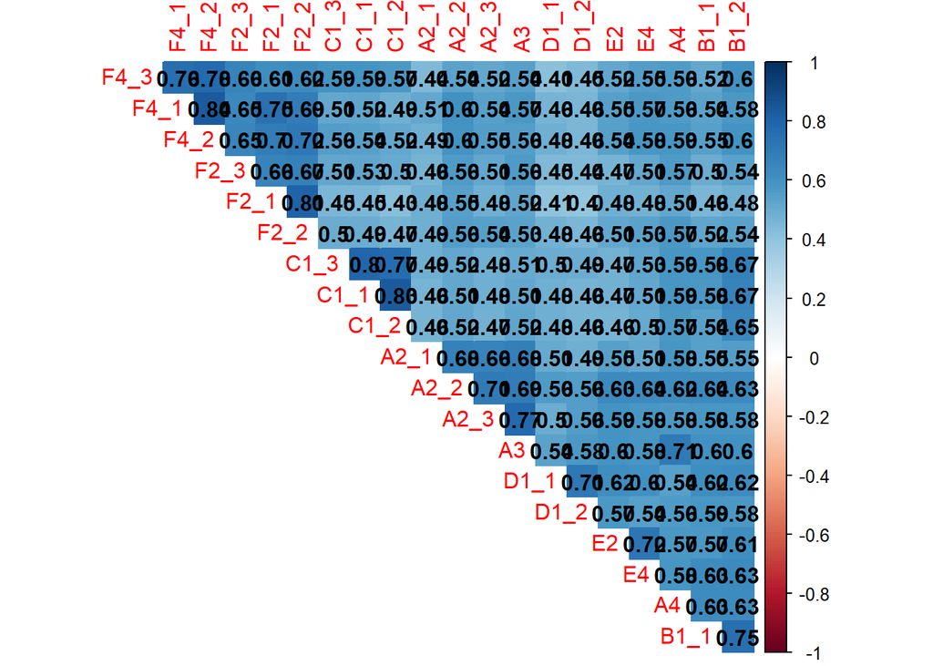

```r
corrplot(cor(dados[ ,8:27]), method="color",order="hclust",addCoef.col = "black",type="upper", diag=FALSE)
```

## ANÁLISE FATORIAL

```r
 pca_result <- prcomp(dados[ ,8:27], scale = TRUE)
  summary(pca_result)
```

```
## Importance of components:
##                           PC1     PC2     PC3     PC4     PC5     PC6
## Standard deviation     3.4213 1.20410 1.10898 0.88450 0.75861 0.68358
## Proportion of Variance 0.5853 0.07249 0.06149 0.03912 0.02877 0.02336
## Cumulative Proportion  0.5853 0.65775 0.71924 0.75836 0.78713 0.81050
##                            PC7     PC8     PC9    PC10    PC11    PC12
## Standard deviation     0.67931 0.65796 0.61865 0.59106 0.54573 0.52612
## Proportion of Variance 0.02307 0.02165 0.01914 0.01747 0.01489 0.01384
## Cumulative Proportion  0.83357 0.85521 0.87435 0.89182 0.90671 0.92055
##                           PC13    PC14    PC15   PC16    PC17    PC18
## Standard deviation     0.51840 0.49225 0.46962 0.4625 0.44172 0.40971
## Proportion of Variance 0.01344 0.01212 0.01103 0.0107 0.00976 0.00839
## Cumulative Proportion  0.93399 0.94610 0.95713 0.9678 0.97758 0.98597
##                          PC19    PC20
## Standard deviation     0.3898 0.35857
## Proportion of Variance 0.0076 0.00643
## Cumulative Proportion  0.9936 1.00000
```

```r
  head(pca_result$x)
```

```
##             PC1        PC2         PC3         PC4        PC5         PC6
## [1,]  0.3832662  2.4438122 -1.99197543  0.78192864 -0.3106604  0.47891278
## [2,]  7.6933796 -0.3351401  0.08161669 -0.08043052 -0.1935910 -0.04056926
## [3,]  2.4747458 -0.3257291  0.24504034 -0.19602141 -0.3786854 -0.23178061
## [4,] -3.4272047  0.2811893 -0.19850094  0.22046742 -0.2264872 -0.15860381
## [5,]  0.3148788 -0.9233233 -0.13895766  1.79155899  0.2894309  0.02007747
## [6,]  3.9556474 -1.7391980  1.23191522  1.48668190  1.2921499 -0.60758215
##              PC7        PC8         PC9        PC10        PC11
## [1,]  0.18974353 -0.7448768 -0.40455222  0.08314443 -0.07734288
## [2,]  0.02200870  0.3135152 -0.62703556 -0.89992719 -0.10504314
## [3,]  0.01408186  0.6441819  0.04342547 -0.42743163 -0.08940120
## [4,]  0.10177305 -0.3599526  0.23905585 -0.03305894 -0.10897716
## [5,]  0.64598124  0.8862709  0.47638082  0.20466143 -0.71113604
## [6,] -1.85531791 -1.1442656  0.19988844 -0.08962806 -0.09903253
##             PC12        PC13        PC14        PC15        PC16
## [1,] -0.03554040 -0.44045709 -0.07916650  0.04927341  0.15354410
## [2,]  0.21324850 -0.02211558  0.17544910  0.16560546 -0.02259853
## [3,]  0.05895615  0.19436128 -0.09329086 -0.07276992  0.35955606
## [4,]  0.42273184  0.15856833 -0.18935542  0.12452525  0.10249453
## [5,]  0.88520560  0.15230555 -0.20411728 -0.98014042  0.33390790
## [6,] -1.14112059 -1.10871201  0.69653647 -1.26297832 -1.10463689
##              PC17       PC18        PC19         PC20
## [1,]  0.172339811 -0.2199655  0.07193791 -0.260488369
## [2,] -0.223312532  0.2108802  0.08247448 -0.106425259
## [3,]  0.592532140 -0.1203097 -0.26724164  0.053494725
## [4,] -0.008583944 -0.2121632 -0.01843003 -0.003247511
## [5,] -0.546980318 -0.7277632  0.18996810  0.217292822
## [6,] -0.243723764  1.1873000 -0.10179775  0.048276514
```

```r
  pca2 <- as.data.frame(pca_result$x)
  dados2 <- data.frame(dados, pca2)
```

## MODELO2

```r
modelo2 <- lm(formula = SATISFACAO_GERAL ~ PC1 + PC2 + PC3 + PC4 + PC5  +  PC6 +PC7  +PC8 + PC9 +PC10 +PC11 + PC12 +PC13 + PC14 + PC15 +PC16 +PC17 +PC18 +PC19 +PC20 + SEXO + RENDA + REGIAO + IDADE,   data = dados2 )

  summary(modelo2)
```

```
##
## Call:
## lm(formula = SATISFACAO_GERAL ~ PC1 + PC2 + PC3 + PC4 + PC5 +
##     PC6 + PC7 + PC8 + PC9 + PC10 + PC11 + PC12 + PC13 + PC14 +
##     PC15 + PC16 + PC17 + PC18 + PC19 + PC20 + SEXO + RENDA +
##     REGIAO + IDADE, data = dados2)
##
## Residuals:
##     Min      1Q  Median      3Q     Max
## -7.5814 -0.8156  0.0347  0.8833  7.9513
##
## Coefficients:
##               Estimate Std. Error t value Pr(>|t|)
## (Intercept)  5.920e+00  2.194e-01  26.976  < 2e-16 ***
## PC1         -6.190e-01  1.553e-02 -39.856  < 2e-16 ***
## PC2          3.275e-01  4.408e-02   7.429 2.55e-13 ***
## PC3         -7.752e-01  4.756e-02 -16.301  < 2e-16 ***
## PC4          1.569e-03  5.953e-02   0.026 0.978980
## PC5         -1.483e-01  6.978e-02  -2.125 0.033864 *
## PC6         -1.497e-01  7.741e-02  -1.934 0.053456 .
## PC7         -2.543e-01  7.776e-02  -3.271 0.001114 **
## PC8         -2.154e-02  8.066e-02  -0.267 0.789513
## PC9         -2.023e-01  8.542e-02  -2.368 0.018113 *
## PC10         4.527e-02  8.925e-02   0.507 0.612124
## PC11        -1.069e-01  9.681e-02  -1.104 0.269721
## PC12         9.622e-02  1.000e-01   0.962 0.336428
## PC13        -3.701e-01  1.020e-01  -3.627 0.000303 ***
## PC14         2.659e-01  1.076e-01   2.472 0.013632 *
## PC15         5.246e-01  1.123e-01   4.672 3.44e-06 ***
## PC16        -5.138e-02  1.141e-01  -0.450 0.652568
## PC17        -6.531e-02  1.196e-01  -0.546 0.584993
## PC18         2.685e-01  1.286e-01   2.087 0.037174 *
## PC19        -1.646e-01  1.357e-01  -1.213 0.225634
## PC20         2.514e-02  1.469e-01   0.171 0.864130
## SEXOM       -2.056e-01  1.093e-01  -1.882 0.060218 .
## RENDA       -5.753e-06  1.025e-05  -0.561 0.574602
## REGIAON      8.159e-02  1.769e-01   0.461 0.644775
## REGIAONE     2.806e-01  1.546e-01   1.815 0.069901 .
## REGIAOS     -6.953e-02  2.224e-01  -0.313 0.754622
## REGIAOSO    -5.877e-02  1.878e-01  -0.313 0.754361
## IDADE       -4.530e-03  4.289e-03  -1.056 0.291158
## ---
## Signif. codes:  0 '***' 0.001 '**' 0.01 '*' 0.05 '.' 0.1 ' ' 1
##
## Residual standard error: 1.594 on 893 degrees of freedom
## Multiple R-squared:  0.6966, Adjusted R-squared:  0.6875
## F-statistic: 75.95 on 27 and 893 DF,  p-value: < 2.2e-16
```

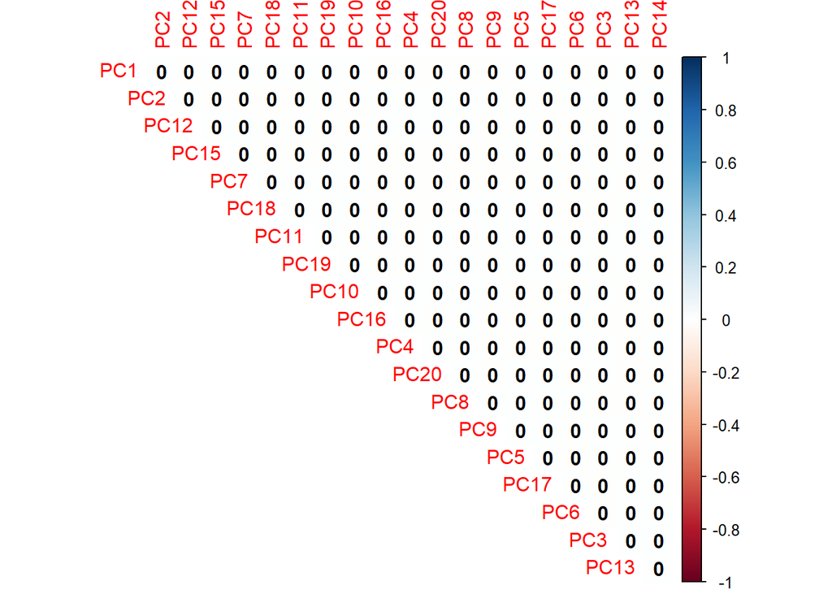

```r
  corrplot(cor(dados2[ ,29:48]), method="color",order="hclust",addCoef.col = "black",type="upper", diag=FALSE)
```

## MODELO 3

```r
modelo3 <- lm(formula = SATISFACAO_GERAL ~  PC1 + SEXO + RENDA + REGIAO + IDADE , data = dados2 )
summary(modelo3)
```

```
##
## Call:
## lm(formula = SATISFACAO_GERAL ~ PC1 + SEXO + RENDA + REGIAO +
##     IDADE, data = dados2)
##
## Residuals:
##     Min      1Q  Median      3Q     Max
## -8.5319 -0.9898  0.1712  1.1624  7.8252
##
## Coefficients:
##               Estimate Std. Error t value Pr(>|t|)
## (Intercept)  6.027e+00  2.541e-01  23.720   <2e-16 ***
## PC1         -6.204e-01  1.844e-02 -33.642   <2e-16 ***
## SEXOM       -9.966e-02  1.283e-01  -0.777   0.4375
## RENDA       -5.373e-06  1.201e-05  -0.447   0.6546
## REGIAON      1.834e-01  2.084e-01   0.880   0.3790
## REGIAONE     3.438e-01  1.820e-01   1.889   0.0592 .
## REGIAOS     -7.948e-02  2.624e-01  -0.303   0.7621
## REGIAOSO    -2.189e-01  2.211e-01  -0.990   0.3224
## IDADE       -8.980e-03  4.922e-03  -1.824   0.0684 .
## ---
## Signif. codes:  0 '***' 0.001 '**' 0.01 '*' 0.05 '.' 0.1 ' ' 1
##
## Residual standard error: 1.893 on 912 degrees of freedom
## Multiple R-squared:  0.5628, Adjusted R-squared:  0.559
## F-statistic: 146.8 on 8 and 912 DF,  p-value: < 2.2e-16
```

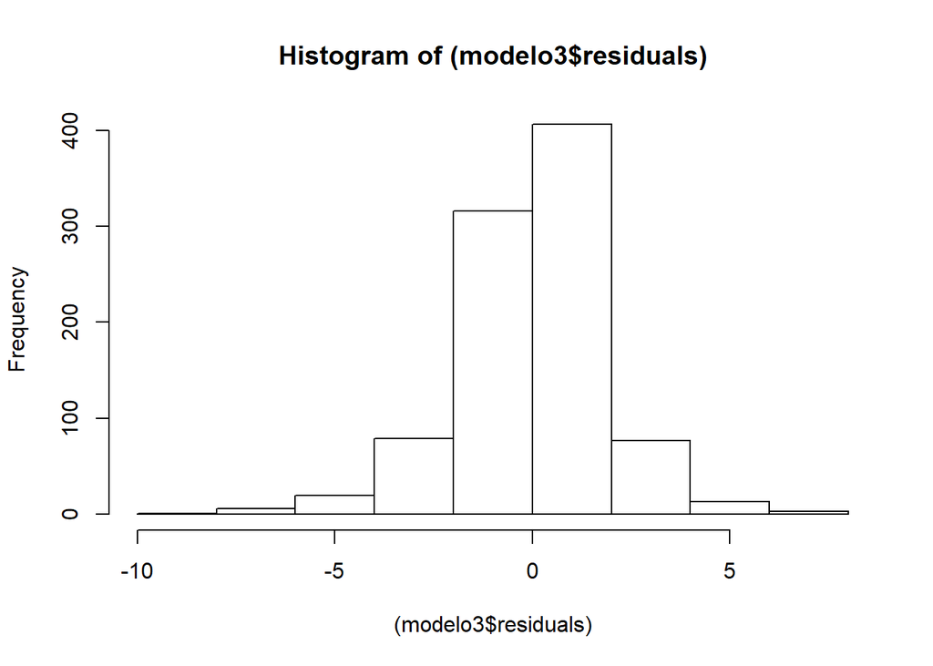

```r
hist((modelo3$residuals))
```

```r
shapiro.test(modelo3$residuals)
```

```
##
##  Shapiro-Wilk normality test
##
## data:  modelo3$residuals
## W = 0.97041, p-value = 9.787e-13
```

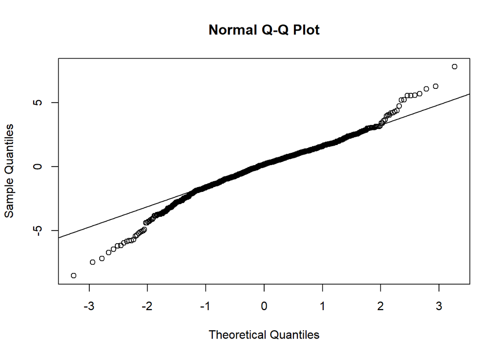

```r
qqnorm(modelo3$residuals)
qqline(modelo3$residuals)
```

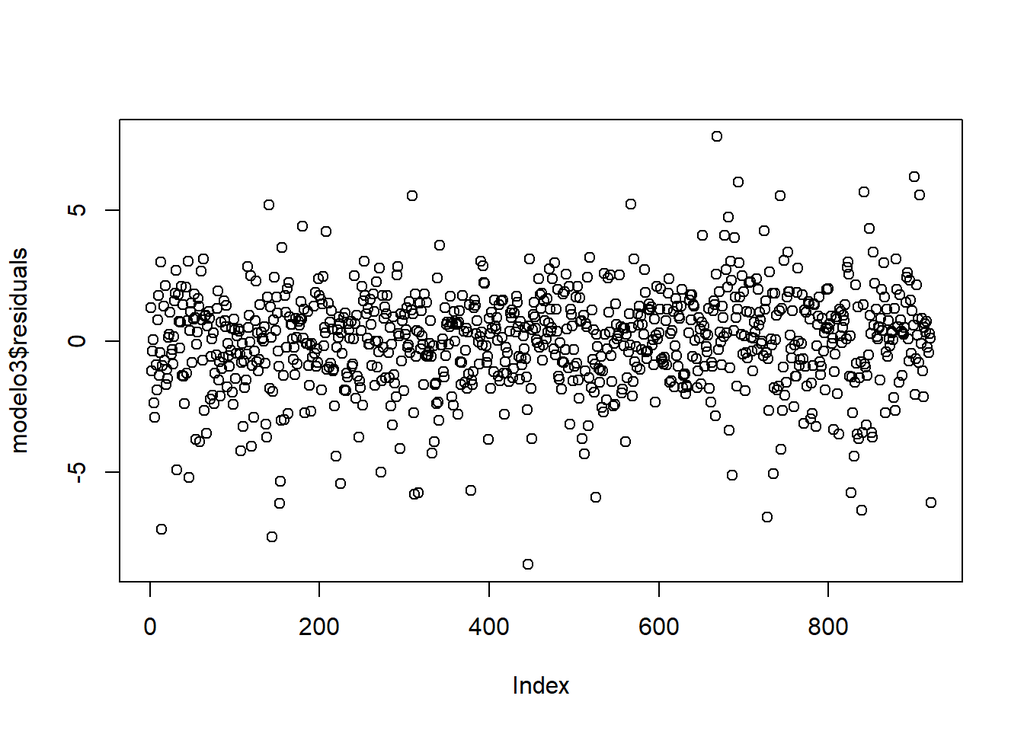

```r
plot(modelo3$residuals)
```

## GRÁFICOS COMPARATIVOS DAS VARIÁVEIS CATEGORICAS

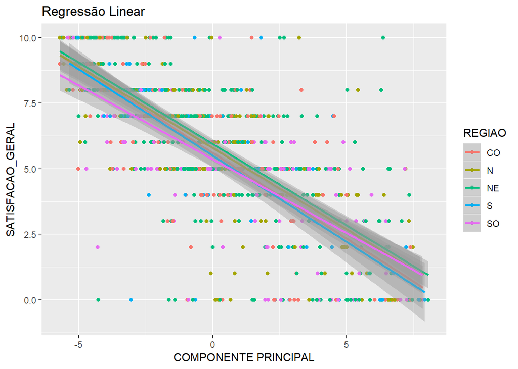

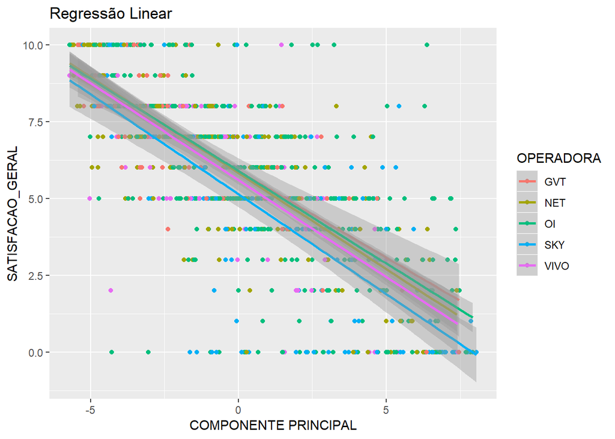

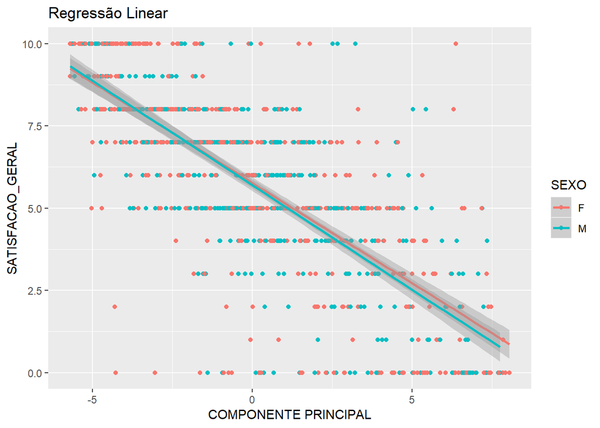